# A Data-Driven Analysis on Climate Change from an Economic Standpoint Project Proposal SDS 3386

Youssef, Shaafici, Thinh, Vinh

2019-10-07

# Problem at Hand

- Climate change and increasing greenhouse gas emissions are gaining political attention
- Industries grow and contribute to economy but produce more emissions
- Regulations are imposed affecting economic growth

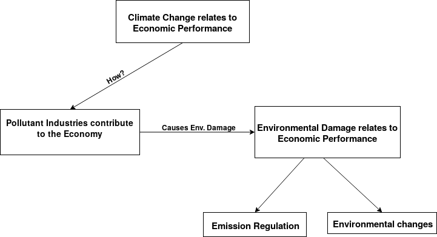

# Objectives

- Measure the impact of pollutant industries on economic development
- Measure the effects of gas emission regulations on industry and economy growth
- Measure the effects(cost) of climate change on global economies (e.g. natural disasters)

# Data sets

- Climate change laws per country (LSE Grantham Research Institute on Climate Change and the Environment)
- National income by activity (data.oecd)
- International greenhouse gas emissions (United Nations via Kaggle)
- Greenhouse gas emissions per country per subsector (CAIT Climate Data Explorer)
- National Footprint Accounts 2018 (Global Footprint Network)

# Methodology

- Find correlations between economic growth and emissions per country and sector
- MultiLevel Regression
- ARIMA or other forecasting methods to forecast future growth and emissions
- Creating a metric for how strong climate change regulations are for each country
- Measure the impact of particular laws to gdp and emissions
- Measure the impact of particular laws to gpd and emissions